# Case Study 1

Lani Lewis

2023-03-18

This area is used to setup R studio for this project

Import in all datasets

```
## 'data.frame':    2410 obs. of  7 variables:
##  $ Name      : chr  "Pub Beer" "Devil's Cup" "Rise of the Phoenix" "Sinister" ...
##  $ Beer_ID   : int  1436 2265 2264 2263 2262 2261 2260 2259 2258 2131 ...
##  $ ABV       : num  0.05 0.066 0.071 0.09 0.075 0.077 0.045 0.065 0.055 0.086 ...
##  $ IBU       : int  NA NA NA NA NA NA NA NA NA NA ...
##  $ Brewery_id: int  409 178 178 178 178 178 178 178 178 178 ...
##  $ Style     : chr  "American Pale Lager" "American Pale Ale (APA)" "American IPA" "American Double / Imperial IPA" ...
##  $ Ounces    : num  12 12 12 12 12 12 12 12 12 12 ...
```

```
## 'data.frame':    558 obs. of  4 variables:
##  $ Brew_ID: int  1 2 3 4 5 6 7 8 9 10 ...
##  $ Name   : chr  "NorthGate Brewing " "Against the Grain Brewery" "Jack's Abby Craft Lagers" "Mike Hess Brewing Company" ...
##  $ City   : chr  "Minneapolis" "Louisville" "Framingham" "San Diego" ...
##  $ State  : chr  " MN" " KY" " MA" " CA" ...
```

```
## 'data.frame':    51 obs. of  3 variables:
##  $ Full_State: chr  "Alabama" "Alaska" "Arizona" "Arkansas" ...
##  $ abbrev    : chr  "Ala." "Alaska" "Ariz." "Ark." ...
##  $ State     : chr  "AL" "AK" "AZ" "AR" ...
```

Handling Missing Data Files for Question #3

```
## 'data.frame':    1005 obs. of  7 variables:
##  $ Name      : chr  "Pub Beer" "Devil's Cup" "Rise of the Phoenix" "Sinister" ...
##  $ Beer_ID   : int  1436 2265 2264 2263 2262 2261 2260 2259 2258 2131 ...
##  $ ABV       : num  0.05 0.066 0.071 0.09 0.075 0.077 0.045 0.065 0.055 0.086 ...
##  $ IBU       : int  NA NA NA NA NA NA NA NA NA NA ...
##  $ Brewery_id: int  409 178 178 178 178 178 178 178 178 178 ...
##  $ Style     : chr  "American Pale Lager" "American Pale Ale (APA)" "American IPA" "American Double / Imperial IPA" ...
##  $ Ounces    : num  12 12 12 12 12 12 12 12 12 12 ...
```

```
## [1] 62
```

```
## [1] 1005
```

Investigation Code Chunk

Plot to show the missing values in correlation to the size of beer, and we see that the smaller beers have more missing values

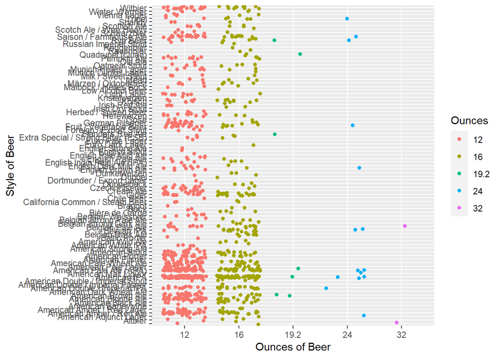

Merge Datasets together for Question #2

```
## 'data.frame':    2410 obs. of  10 variables:
##  $ Brew_ID  : int  1 1 1 1 1 1 2 2 2 2 ...
##  $ Beer_Name: chr  "Get Together" "Maggie's Leap" "Wall's End" "Pumpion" ...
##  $ Beer_ID  : int  2692 2691 2690 2689 2688 2687 2686 2685 2684 2683 ...
##  $ ABV      : num  0.045 0.049 0.048 0.06 0.06 0.056 0.08 0.125 0.077 0.042 ...
##  $ IBU      : int  50 26 19 38 25 47 68 80 25 42 ...
##  $ Style    : chr  "American IPA" "Milk / Sweet Stout" "English Brown Ale" "Pumpkin Ale" ...
##  $ Ounces   : num  16 16 16 16 16 16 16 16 16 16 ...
##  $ Brewery  : chr  "NorthGate Brewing " "NorthGate Brewing " "NorthGate Brewing " "NorthGate Brewing " ...
##  $ City     : chr  "Minneapolis" "Minneapolis" "Minneapolis" "Minneapolis" ...
##  $ State    : chr  " MN" " MN" " MN" " MN" ...
```

Handle Missing Values for Question #3

Replace ABV and IBU missing values with Styled median values. This way when we go to grab the median or results wont be so skewed. Especially since we have close to half of the data set missing values.

```
## 'data.frame':    2410 obs. of  10 variables:
##  $ Brew_ID  : int  1 1 1 1 1 1 2 2 2 2 ...
##  $ Beer_Name: chr  "Get Together" "Maggie's Leap" "Wall's End" "Pumpion" ...
##  $ Beer_ID  : int  2692 2691 2690 2689 2688 2687 2686 2685 2684 2683 ...
##  $ ABV      : num  0.045 0.049 0.048 0.06 0.06 0.056 0.08 0.125 0.077 0.042 ...
##  $ IBU      : num  55 25 19 38 25 47 65 80 25 35 ...
##  $ Style    : Factor w/ 100 levels "","Abbey Single Ale",..: 16 77 48 83 22 57 12 46 77 18 ...
##  $ Ounces   : num  16 16 16 16 16 16 16 16 16 16 ...
##  $ Brewery  : chr  "NorthGate Brewing " "NorthGate Brewing " "NorthGate Brewing " "NorthGate Brewing " ...
##  $ City     : chr  "Minneapolis" "Minneapolis" "Minneapolis" "Minneapolis" ...
##  $ State    : chr  " MN" " MN" " MN" " MN" ...
```

Compute the median alcohol content and international bitterness unit for each state. Question #4

```
## data frame with 0 columns and 50 rows
```

```
## # A tibble: 51 × 2
##    State IBU_Median
##    <chr>      <dbl>
##  1 " NJ"       55
##  2 " WV"       53
##  3 " AL"       35
##  4 " MN"       35
##  5 " ND"       35
##  6 " VA"       34
##  7 " TN"       33.5
##  8 " MS"       31
##  9 " DE"       30
## 10 " AK"       25
## # … with 41 more rows
```

```
## # A tibble: 51 × 2
##    State median
##    <chr>  <dbl>
##  1 " KY" 0.065
##  2 " DC" 0.0625
##  3 " NV" 0.062
##  4 " WV" 0.062
##  5 " NM" 0.061
##  6 " AL" 0.06
##  7 " CO" 0.06
##  8 " CT" 0.06
##  9 " DE" 0.06
## 10 " MI" 0.06
## # … with 41 more rows
```

```
##    State IBU_Median ABV_Median
## 1     AK       25.0    0.05600
## 2     AL       35.0    0.06000
## 3     AR       25.0    0.05200
## 4     AZ       25.0    0.05500
## 5     CA       25.0    0.05800
## 6     CO       25.0    0.06000
## 7     CT       25.0    0.06000
## 8     DC       25.0    0.06250
## 9     DE       30.0    0.06000
## 10    FL       25.0    0.05550
## 11    GA       25.0    0.05500
## 12    HI       25.0    0.05400
## 13    IA       25.0    0.05550
## 14    ID       25.0    0.05650
```

[output cut: 37 more lines]

```
## 'data.frame':    51 obs. of  5 variables:
##  $ State     : chr  "AK" "AL" "AR" "AZ" ...
##  $ IBU_Median: num  25 35 25 25 25 25 25 25 30 25 ...
##  $ ABV_Median: num  0.056 0.06 0.052 0.055 0.058 0.06 0.06 0.0625 0.06 0.0555 ...
##  $ Full_State: chr  "Alaska" "Alabama" "Arkansas" "Arizona" ...
##  $ abbrev    : chr  "Alaska" "Ala." "Ark." "Ariz." ...
```

```
## 'data.frame':    2410 obs. of  10 variables:
##  $ Brew_ID  : int  1 1 1 1 1 1 2 2 2 2 ...
##  $ Beer_Name: chr  "Get Together" "Maggie's Leap" "Wall's End" "Pumpion" ...
##  $ Beer_ID  : int  2692 2691 2690 2689 2688 2687 2686 2685 2684 2683 ...
##  $ ABV      : num  0.045 0.049 0.048 0.06 0.06 0.056 0.08 0.125 0.077 0.042 ...
##  $ IBU      : num  55 25 19 38 25 47 65 80 25 35 ...
##  $ Style    : Factor w/ 100 levels "","Abbey Single Ale",..: 16 77 48 83 22 57 12 46 77 18 ...
##  $ Ounces   : num  16 16 16 16 16 16 16 16 16 16 ...
##  $ Brewery  : chr  "NorthGate Brewing " "NorthGate Brewing " "NorthGate Brewing " "NorthGate Brewing " ...
##  $ City     : chr  "Minneapolis" "Minneapolis" "Minneapolis" "Minneapolis" ...
##  $ State    : chr  " MN" " MN" " MN" " MN" ...
```

```
## 'data.frame':    2410 obs. of  10 variables:
##  $ Brew_ID  : int  1 1 1 1 1 1 2 2 2 2 ...
##  $ Beer_Name: chr  "Get Together" "Maggie's Leap" "Wall's End" "Pumpion" ...
##  $ Beer_ID  : int  2692 2691 2690 2689 2688 2687 2686 2685 2684 2683 ...
##  $ ABV      : num  0.045 0.049 0.048 0.06 0.06 0.056 0.08 0.125 0.077 0.042 ...
##  $ IBU      : num  55 25 19 38 25 47 65 80 25 35 ...
##  $ Style    : Factor w/ 100 levels "","Abbey Single Ale",..: 16 77 48 83 22 57 12 46 77 18 ...
##  $ Ounces   : num  16 16 16 16 16 16 16 16 16 16 ...
##  $ Brewery  : chr  "NorthGate Brewing " "NorthGate Brewing " "NorthGate Brewing " "NorthGate Brewing " ...
##  $ City     : chr  "Minneapolis" "Minneapolis" "Minneapolis" "Minneapolis" ...
##  $ State    : chr  " MN" " MN" " MN" " MN" ...
```

```
## 'data.frame':    51 obs. of  4 variables:
##  $ State           : chr  "AK" "AL" "AR" "AZ" ...
##  $ Number_of_States: int  25 10 5 47 183 265 27 8 2 58 ...
##  $ Full_State      : chr  "Alaska" "Alabama" "Arkansas" "Arizona" ...
##  $ abbrev          : chr  "Alaska" "Ala." "Ark." "Ariz." ...
```

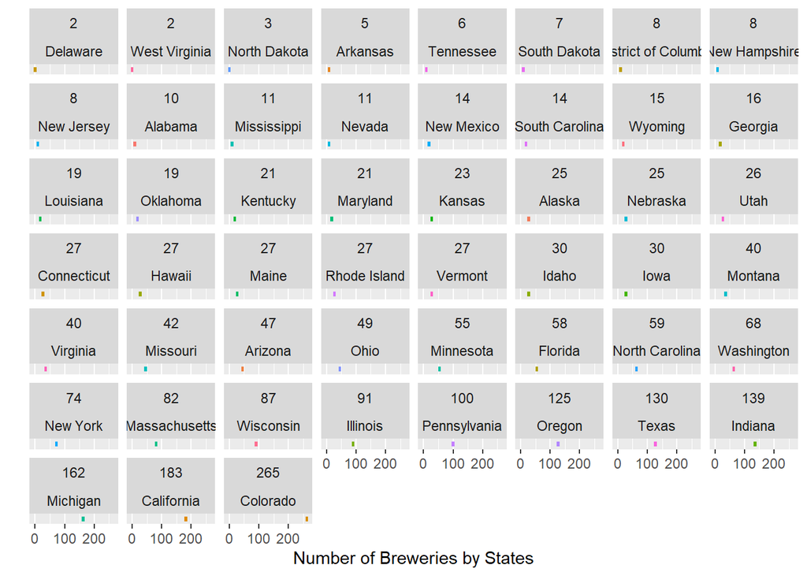

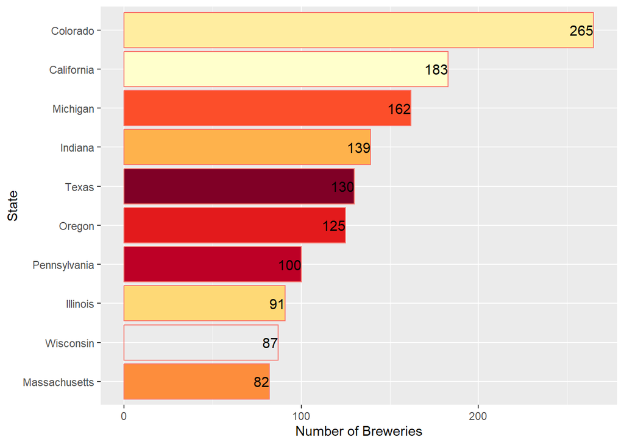

Median Charts for Question #4

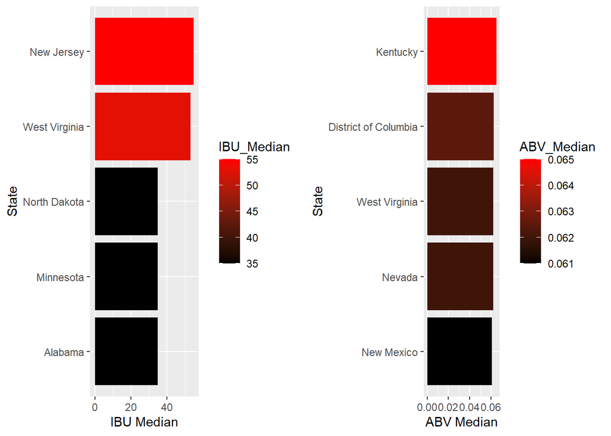

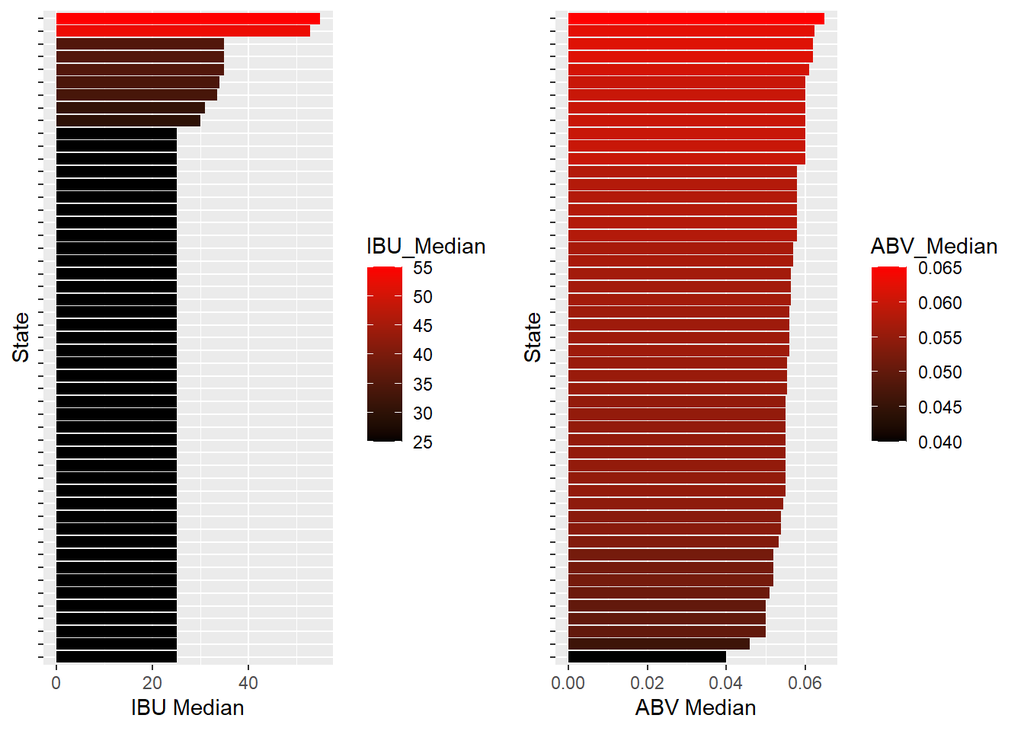

Breakdown of of Median values by State

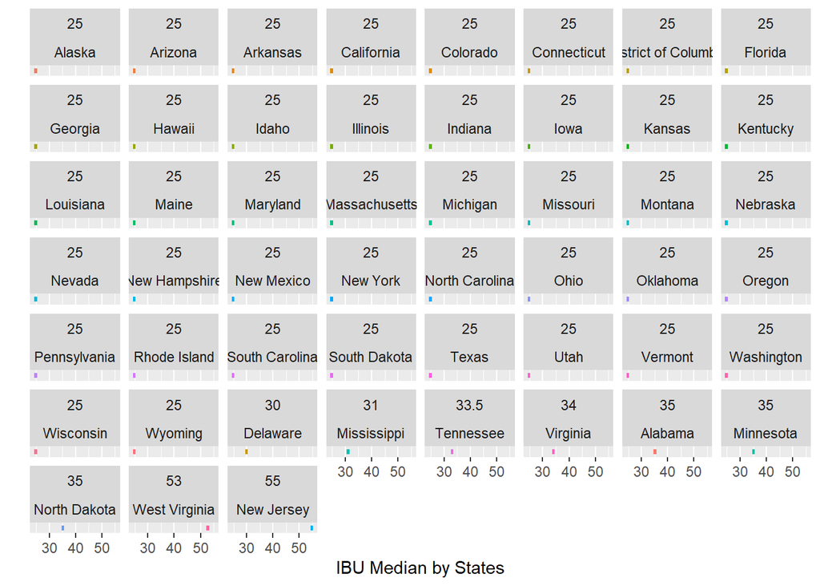

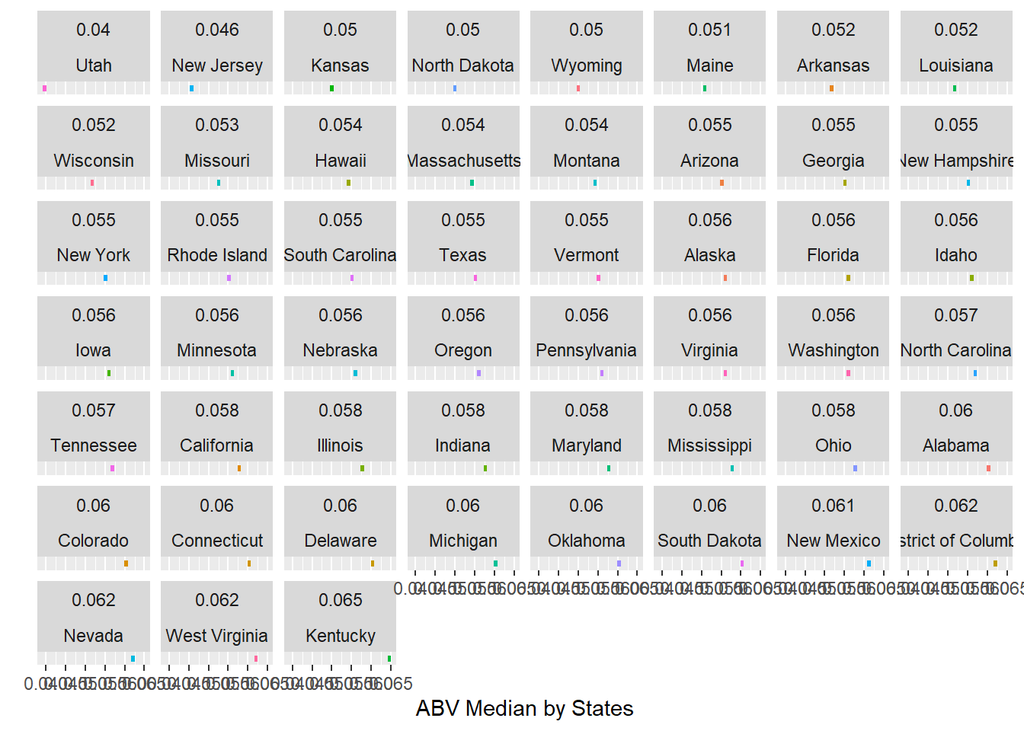

Review the Summary Data of the data sets for Question #6

```
##     Brew_ID       Beer_Name            Beer_ID            ABV
##  Min.   :  1.0   Length:2410        Min.   :   1.0   Min.   :0.00100
##  1st Qu.: 94.0   Class :character   1st Qu.: 808.2   1st Qu.:0.05000
##  Median :206.0   Mode  :character   Median :1453.5   Median :0.05600
##  Mean   :232.7                      Mean   :1431.1   Mean   :0.05972
##  3rd Qu.:367.0                      3rd Qu.:2075.8   3rd Qu.:0.06700
##  Max.   :558.0                      Max.   :2692.0   Max.   :0.12800
##
##       IBU                                    Style          Ounces
##  Min.   :  4.00   American IPA                  : 424   Min.   : 8.40
##  1st Qu.: 25.00   American Pale Ale (APA)       : 245   1st Qu.:12.00
##  Median : 25.00   American Amber / Red Ale      : 133   Median :12.00
##  Mean   : 30.19   American Blonde Ale           : 108   Mean   :13.59
##  3rd Qu.: 35.00   American Double / Imperial IPA: 105   3rd Qu.:16.00
##  Max.   :100.00   American Pale Wheat Ale       :  97   Max.   :32.00
##                   (Other)                       :1298
##    Brewery              City              State
##  Length:2410        Length:2410        Length:2410
##  Class :character   Class :character   Class :character
##  Mode  :character   Mode  :character   Mode  :character
##
##
##
##
```

```
##     State             IBU_Median      ABV_Median       Full_State
##  Length:51          Min.   :25.00   Min.   :0.04000   Length:51
##  Class :character   1st Qu.:25.00   1st Qu.:0.05450   Class :character
##  Mode  :character   Median :25.00   Median :0.05600   Mode  :character
##                     Mean   :27.28   Mean   :0.05592
##                     3rd Qu.:25.00   3rd Qu.:0.05800
##                     Max.   :55.00   Max.   :0.06500
##     abbrev
##  Length:51
##  Class :character
##  Mode  :character
##
##
##
```

```
##    State IBU_Median ABV_Median Full_State abbrev
## 18    KY         25      0.065   Kentucky    Ky.
```

```
##    State IBU_Median ABV_Median Full_State abbrev
## 32    NJ         55      0.046 New Jersey   N.J.
```

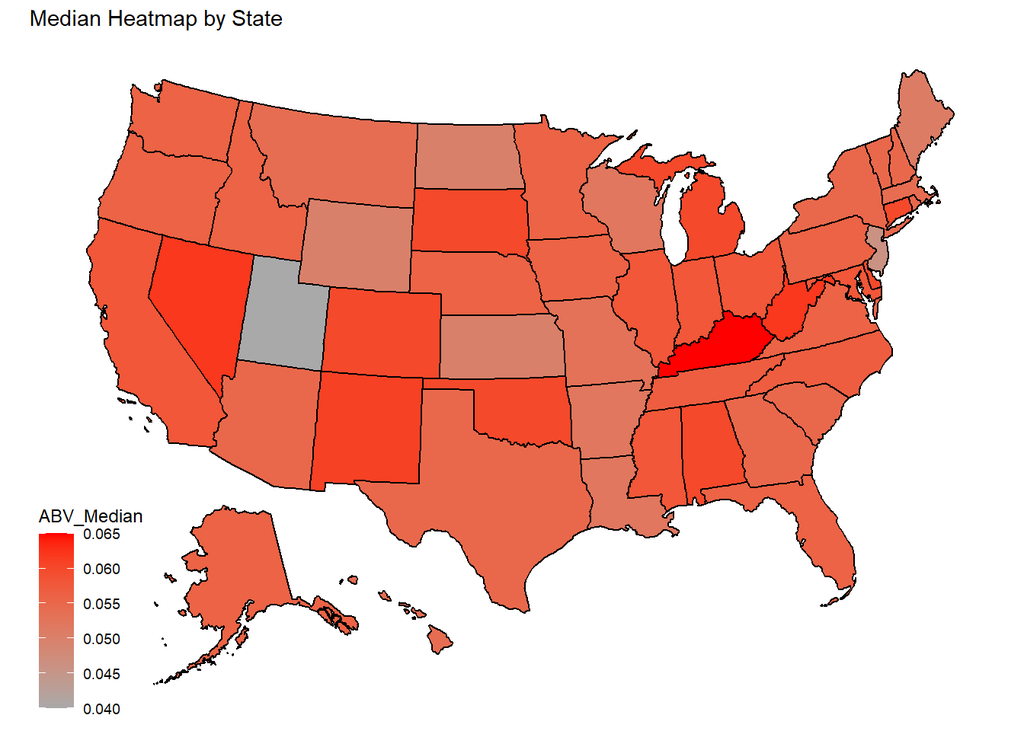

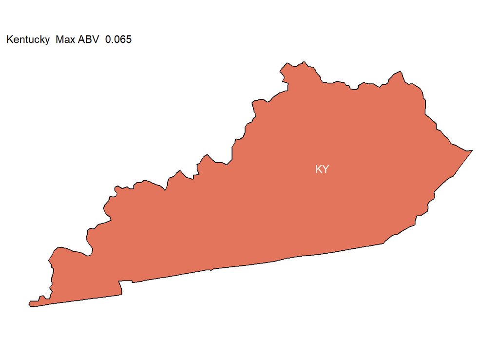

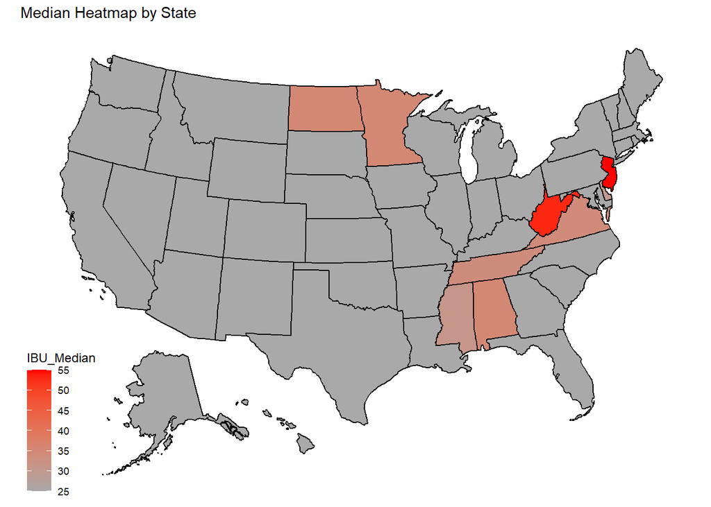

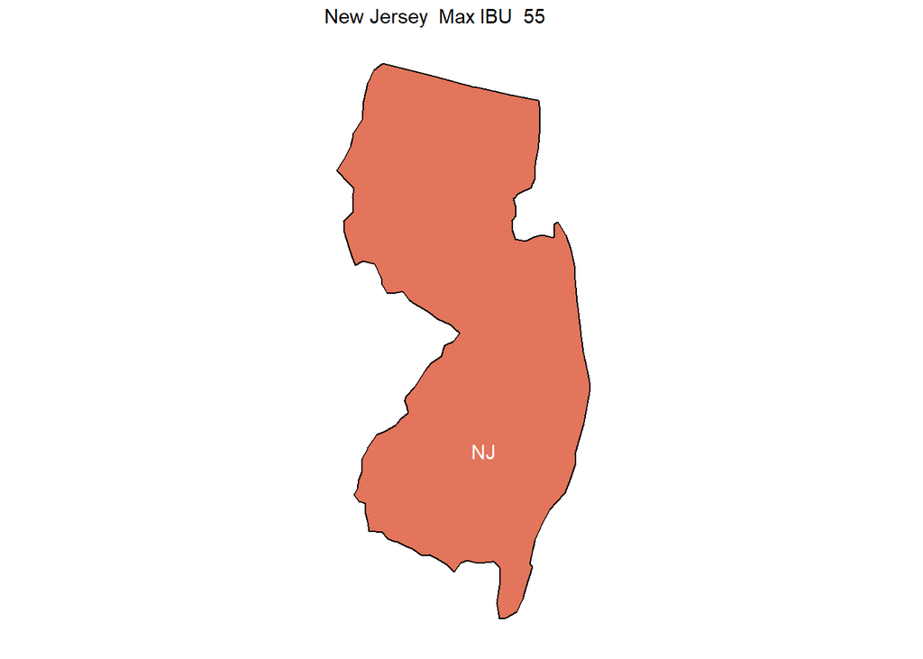

Question #7: Is there an apparent relationship between the bitterness of the beer and its alcoholic content?

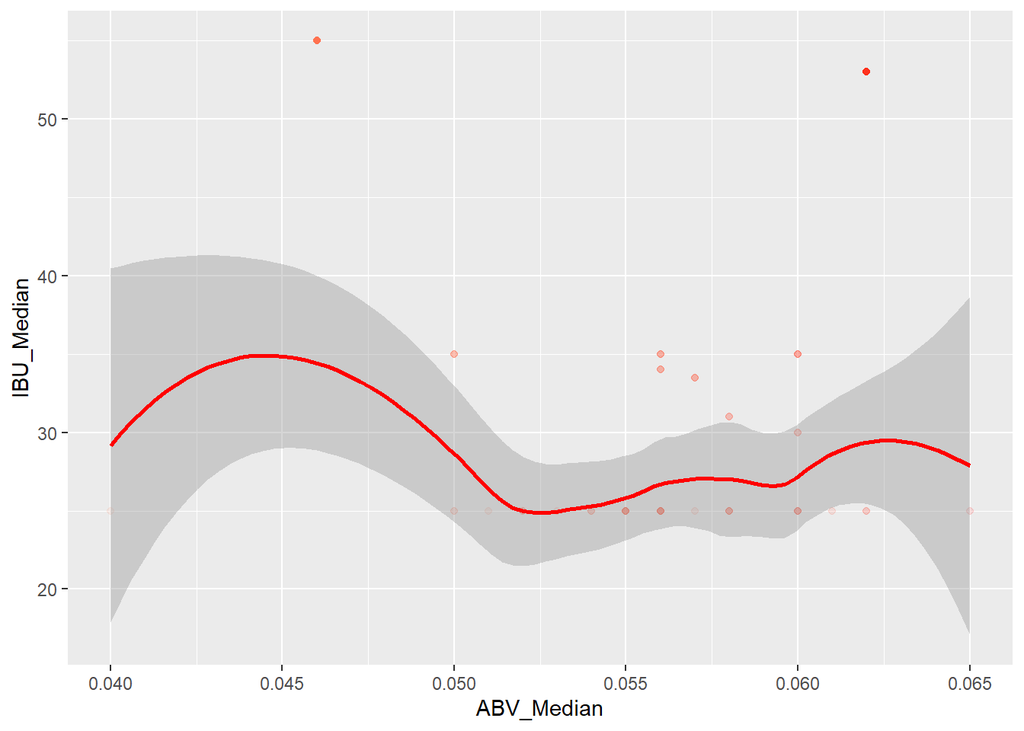

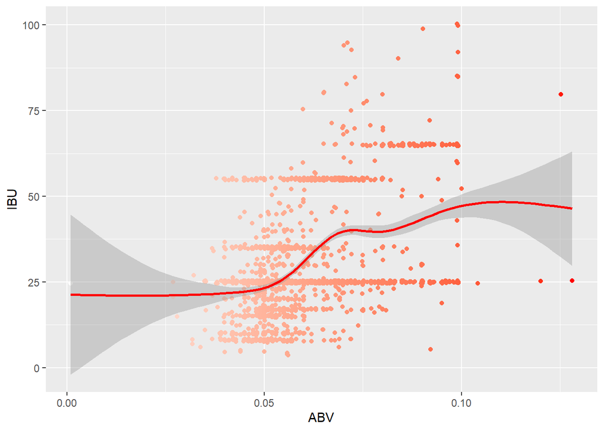

What is the probability of picking a beer like Budweiser lager in this list of craft beers.

```
## [1] Cream Ale
## attr(,"prob")
## [1] 0.375
## 100 Levels:  Abbey Single Ale Altbier ... Witbier
```

Question #8 - difference with respect to IBU and ABV between IPAs (India Pale Ales) and other types of Ale (any beer with “Ale” in its name other than IPA).

What is the probability that we will find similar style beers within the entire dataset based off the ABV and IBU

```
## Confusion Matrix and Statistics
##
##
## class4 Ale IPA
##    Ale 907  75
##    IPA  69 483
##
##                Accuracy : 0.9061
##                  95% CI : (0.8904, 0.9203)
##     No Information Rate : 0.6362
##     P-Value [Acc > NIR] : <2e-16
##
##                   Kappa : 0.7967
##
##  Mcnemar's Test P-Value : 0.6769
##
##             Sensitivity : 0.9293
##             Specificity : 0.8656
##          Pos Pred Value : 0.9236
##          Neg Pred Value : 0.8750
##              Prevalence : 0.6362
##          Detection Rate : 0.5913
##    Detection Prevalence : 0.6402
##       Balanced Accuracy : 0.8974
##
##        'Positive' Class : Ale
##
```